# Team 5 - Data 624 - Project 2

Ohannes (Hovig) Ohannessian, Niteen Kumar, Gurpreet Singh, Peter Goodridge

4/20/2019

## Initialize and Load Data

```r
student_evaluation_gh_file <- "https://github.com/hovig/Team5-Data624-Project2/raw/master/StudentEvaluation.xlsx"

se_temp_file <- tempfile(fileext = ".xlsx")

se_data <- GET(student_evaluation_gh_file, authenticate(Sys.getenv("GITHUB_PAT"), ""), write_disk(path = se_temp_file))

se_data <- readxl::read_excel(se_temp_file)

bev_raw <- read_csv('https://raw.githubusercontent.com/hovig/Team5-Data624-Project2/master/StudentData.csv') #%>%
#drop_na(PH)
```

## Explore and Process Data

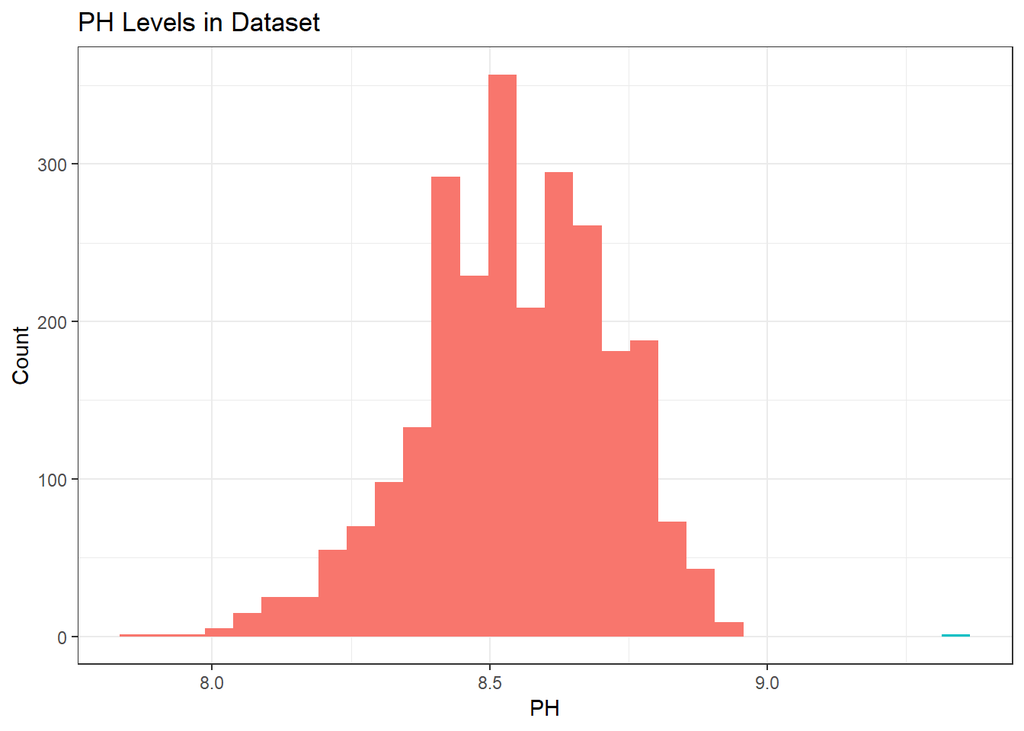

```r
bev_raw %>%
  ggplot(aes(PH, fill=PH > 9)) +
  geom_histogram(bins=30) +
  theme_bw() +
  theme(legend.position='center') +
  labs(y='Count', title='PH Levels in Dataset')
```

```r
bev_raw <- bev_raw %>% filter(!is.na(bev_raw$PH), bev_raw$PH < 9)
```

```r
dim(bev_raw)
```

```
## [1] 2566   33
```

```r
str(bev_raw)
```

```
## Classes 'spec_tbl_df', 'tbl_df', 'tbl' and 'data.frame': 2566 obs. of  33 variables:
##  $ Brand Code       : chr  "B" "A" "B" "A" ...
##  $ Carb Volume      : num  5.34 5.43 5.29 5.44 5.49 ...
##  $ Fill Ounces      : num  24 24 24.1 24 24.3 ...
##  $ PC Volume        : num  0.263 0.239 0.263 0.293 0.111 ...
##  $ Carb Pressure    : num  68.2 68.4 70.8 63 67.2 66.6 64.2 67.6 64.2 72 ...
##  $ Carb Temp        : num  141 140 145 133 137 ...
##  $ PSC              : num  0.104 0.124 0.09 NA 0.026 0.09 0.128 0.154 0.132 0.014 ...
##  $ PSC Fill         : num  0.26 0.22 0.34 0.42 0.16 0.24 0.4 0.34 0.12 0.24 ...
##  $ PSC CO2          : num  0.04 0.04 0.16 0.04 0.12 0.04 0.04 0.04 0.14 0.06 ...
##  $ Mnf Flow         : num  -100 -100 -100 -100 -100 -100 -100 -100 -100 -100 ...
##  $ Carb Pressure1   : num  119 122 120 115 118 ...
##  $ Fill Pressure    : num  46 46 46 46.4 45.8 45.6 51.8 46.8 46 45.2 ...
##  $ Hyd Pressure1    : num  0 0 0 0 0 0 0 0 0 0 ...
##  $ Hyd Pressure2    : num  NA NA NA 0 0 0 0 0 0 0 ...
##  $ Hyd Pressure3    : num  NA NA NA 0 0 0 0 0 0 0 ...
##  $ Hyd Pressure4    : num  118 106 82 92 92 116 124 132 90 108 ...
##  $ Filler Level     : num  121 119 120 118 119 ...
##  $ Filler Speed     : num  4002 3986 4020 4012 4010 ...
##  $ Temperature      : num  66 67.6 67 65.6 65.6 66.2 65.8 65.2 65.4 66.6 ...
##  $ Usage cont       : num  16.2 19.9 17.8 17.4 17.7 ...
##  $ Carb Flow        : num  2932 3144 2914 3062 3054 ...
##  $ Density          : num  0.88 0.92 1.58 1.54 1.54 1.52 0.84 0.84 0.9 0.9 ...
##  $ MFR              : num  725 727 735 731 723 ...
##  $ Balling          : num  1.4 1.5 3.14 3.04 3.04 ...
##  $ Pressure Vacuum  : num  -4 -4 -3.8 -4.4 -4.4 -4.4 -4.4 -4.4 -4.4 -4.4 ...
##  $ PH               : num  8.36 8.26 8.94 8.24 8.26 8.32 8.4 8.38 8.38 8.5 ...
##  $ Oxygen Filler    : num  0.022 0.026 0.024 0.03 0.03 0.024 0.066 0.046 0.064 0.022 ...
##  $ Bowl Setpoint    : num  120 120 120 120 120 120 120 120 120 120 ...
##  $ Pressure Setpoint: num  46.4 46.8 46.6 46 46 46 46 46 46 46 ...
##  $ Air Pressurer    : num  143 143 142 146 146 ...
##  $ Alch Rel         : num  6.58 6.56 7.66 7.14 7.14 7.16 6.54 6.52 6.52 6.54 ...
##  $ Carb Rel         : num  5.32 5.3 5.84 5.42 5.44 5.44 5.38 5.34 5.34 5.34 ...
##  $ Balling Lvl      : num  1.48 1.56 3.28 3.04 3.04 3.02 1.44 1.44 1.44 1.38 ...
##  - attr(*, "spec")=
##   .. cols(
##   ..   `Brand Code` = col_character(),
##   ..   `Carb Volume` = col_double(),
##   ..   `Fill Ounces` = col_double(),
##   ..   `PC Volume` = col_double(),
```

[output cut: 15 more lines]

```
##   ..   `Usage cont` = col_double(),
##   ..   `Carb Flow` = col_double(),
##   ..   Density = col_double(),
##   ..   MFR = col_double(),
##   ..   Balling = col_double(),
##   ..   `Pressure Vacuum` = col_double(),
##   ..   PH = col_double(),
##   ..   `Oxygen Filler` = col_double(),
##   ..   `Bowl Setpoint` = col_double(),
##   ..   `Pressure Setpoint` = col_double(),
##   ..   `Air Pressurer` = col_double(),
##   ..   `Alch Rel` = col_double(),
##   ..   `Carb Rel` = col_double(),
##   ..   `Balling Lvl` = col_double()
##   .. )
```

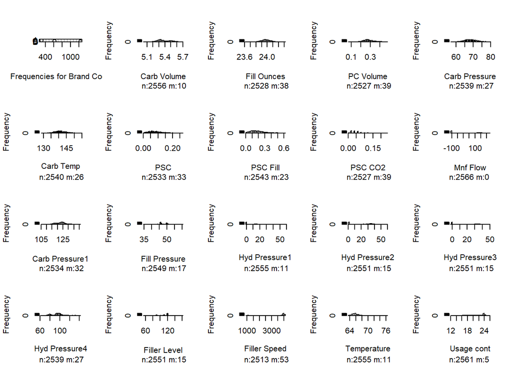

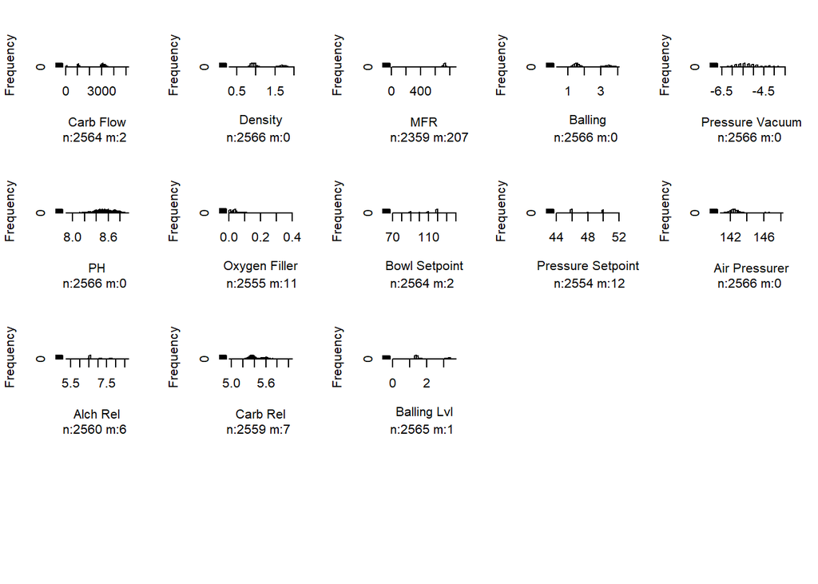

```r
hist.data.frame(bev_raw)
```

```r
table(bev_raw$`Brand Code`)
```

```
##
##    A    B    C    D
##  293 1235  303  615
```

```r
summary(bev_raw)
```

```
##   Brand Code         Carb Volume     Fill Ounces      PC Volume
##  Length:2566        Min.   :5.040   Min.   :23.63   Min.   :0.07933
##  Class :character   1st Qu.:5.293   1st Qu.:23.92   1st Qu.:0.23933
##  Mode  :character   Median :5.347   Median :23.97   Median :0.27133
##                     Mean   :5.370   Mean   :23.97   Mean   :0.27719
##                     3rd Qu.:5.453   3rd Qu.:24.03   3rd Qu.:0.31200
##                     Max.   :5.700   Max.   :24.32   Max.   :0.47800
##                     NA's   :10      NA's   :38      NA's   :39
##  Carb Pressure     Carb Temp          PSC             PSC Fill
##  Min.   :57.00   Min.   :128.6   Min.   :0.00200   Min.   :0.0000
##  1st Qu.:65.60   1st Qu.:138.4   1st Qu.:0.04800   1st Qu.:0.1000
##  Median :68.20   Median :140.8   Median :0.07600   Median :0.1800
##  Mean   :68.19   Mean   :141.1   Mean   :0.08468   Mean   :0.1953
##  3rd Qu.:70.60   3rd Qu.:143.8   3rd Qu.:0.11200   3rd Qu.:0.2600
##  Max.   :79.40   Max.   :154.0   Max.   :0.27000   Max.   :0.6200
##  NA's   :27      NA's   :26      NA's   :33        NA's   :23
##     PSC CO2           Mnf Flow       Carb Pressure1  Fill Pressure
##  Min.   :0.00000   Min.   :-100.20   Min.   :105.6   Min.   :34.60
##  1st Qu.:0.02000   1st Qu.:-100.00   1st Qu.:119.0   1st Qu.:46.00
##  Median :0.04000   Median :  70.70   Median :123.2   Median :46.40
##  Mean   :0.05645   Mean   :  24.68   Mean   :122.6   Mean   :47.92
##  3rd Qu.:0.08000   3rd Qu.: 140.80   3rd Qu.:125.4   3rd Qu.:50.00
##  Max.   :0.24000   Max.   : 229.40   Max.   :140.2   Max.   :60.40
##  NA's   :39                          NA's   :32      NA's   :17
##  Hyd Pressure1   Hyd Pressure2  Hyd Pressure3   Hyd Pressure4
##  Min.   :-0.80   Min.   : 0.0   Min.   :-1.20   Min.   : 62.00
##  1st Qu.: 0.00   1st Qu.: 0.0   1st Qu.: 0.00   1st Qu.: 86.00
##  Median :11.40   Median :28.6   Median :27.60   Median : 96.00
##  Mean   :12.46   Mean   :21.0   Mean   :20.49   Mean   : 96.31
##  3rd Qu.:20.20   3rd Qu.:34.6   3rd Qu.:33.40   3rd Qu.:102.00
##  Max.   :58.00   Max.   :59.4   Max.   :50.00   Max.   :142.00
##  NA's   :11      NA's   :15     NA's   :15      NA's   :27
##   Filler Level    Filler Speed   Temperature      Usage cont
##  Min.   : 55.8   Min.   : 998   Min.   :63.60   Min.   :12.08
##  1st Qu.: 98.3   1st Qu.:3888   1st Qu.:65.20   1st Qu.:18.38
##  Median :118.4   Median :3982   Median :65.60   Median :21.80
##  Mean   :109.3   Mean   :3688   Mean   :65.96   Mean   :21.00
##  3rd Qu.:120.0   3rd Qu.:3998   3rd Qu.:66.40   3rd Qu.:23.76
##  Max.   :161.2   Max.   :4030   Max.   :76.20   Max.   :25.90
##  NA's   :15      NA's   :53     NA's   :11      NA's   :5
```

[output cut: 17 more lines]

```
##  Min.   :44.00     Min.   :140.8   Min.   :5.280   Min.   :4.960
##  1st Qu.:46.00     1st Qu.:142.2   1st Qu.:6.540   1st Qu.:5.340
##  Median :46.00     Median :142.6   Median :6.560   Median :5.400
##  Mean   :47.61     Mean   :142.8   Mean   :6.898   Mean   :5.437
##  3rd Qu.:50.00     3rd Qu.:143.0   3rd Qu.:7.240   3rd Qu.:5.550
##  Max.   :52.00     Max.   :148.2   Max.   :8.620   Max.   :6.060
##  NA's   :12                        NA's   :6       NA's   :7
##   Balling Lvl
##  Min.   :0.000
##  1st Qu.:1.380
##  Median :1.480
##  Mean   :2.052
##  3rd Qu.:3.140
##  Max.   :3.660
##  NA's   :1
```

```r
describe(bev_raw %>% select(-`Brand Code`))
```

```
##                   vars    n    mean      sd  median trimmed    mad     min
## Carb Volume          1 2556    5.37    0.11    5.35    5.37   0.11    5.04
## Fill Ounces          2 2528   23.97    0.09   23.97   23.98   0.08   23.63
## PC Volume            3 2527    0.28    0.06    0.27    0.27   0.05    0.08
## Carb Pressure        4 2539   68.19    3.54   68.20   68.12   3.56   57.00
## Carb Temp            5 2540  141.09    4.03  140.80  140.99   3.85  128.60
## PSC                  6 2533    0.08    0.05    0.08    0.08   0.05    0.00
## PSC Fill             7 2543    0.20    0.12    0.18    0.18   0.12    0.00
## PSC CO2              8 2527    0.06    0.04    0.04    0.05   0.03    0.00
## Mnf Flow             9 2566   24.68  119.50   70.70   21.20 160.57 -100.20
## Carb Pressure1      10 2534  122.56    4.72  123.20  122.52   4.45  105.60
## Fill Pressure       11 2549   47.92    3.18   46.40   47.71   2.37   34.60
## Hyd Pressure1       12 2555   12.46   12.43   11.40   10.87  16.90   -0.80
## Hyd Pressure2       13 2551   21.00   16.38   28.60   21.10  13.34    0.00
## Hyd Pressure3       14 2551   20.49   15.97   27.60   20.54  13.64   -1.20
## Hyd Pressure4       15 2539   96.31   13.10   96.00   95.46  11.86   62.00
## Filler Level        16 2551  109.25   15.70  118.40  111.04   9.19   55.80
## Filler Speed        17 2513 3688.11  769.63 3982.00 3920.25  47.44  998.00
## Temperature         18 2555   65.96    1.38   65.60   65.80   0.89   63.60
## Usage cont          19 2561   21.00    2.98   21.80   21.25   3.17   12.08
## Carb Flow           20 2564 2473.00 1069.56 3030.00 2604.91 323.21   26.00
## Density             21 2566    1.17    0.38    0.98    1.15   0.15    0.30
## MFR                 22 2359  704.05   73.90  724.00  718.16  15.42   31.40
## Balling             23 2566    2.20    0.93    1.65    2.13   0.37    0.35
## Pressure Vacuum     24 2566   -5.22    0.57   -5.40   -5.25   0.59   -6.60
## PH                  25 2566    8.55    0.17    8.54    8.55   0.18    7.88
## Oxygen Filler       26 2555    0.05    0.04    0.03    0.04   0.02    0.00
## Bowl Setpoint       27 2564  109.34   15.29  120.00  111.36   0.00   70.00
## Pressure Setpoint   28 2554   47.61    2.04   46.00   47.60   0.00   44.00
## Air Pressurer       29 2566  142.83    1.21  142.60  142.58   0.59  140.80
## Alch Rel            30 2560    6.90    0.51    6.56    6.84   0.06    5.28
## Carb Rel            31 2559    5.44    0.13    5.40    5.43   0.12    4.96
## Balling Lvl         32 2565    2.05    0.87    1.48    1.98   0.21    0.00
##                       max   range  skew kurtosis    se
## Carb Volume          5.70    0.66  0.39    -0.47  0.00
## Fill Ounces         24.32    0.69 -0.02     0.87  0.00
## PC Volume            0.48    0.40  0.35     0.67  0.00
## Carb Pressure       79.40   22.40  0.18    -0.01  0.07
## Carb Temp          154.00   25.40  0.24     0.23  0.08
## PSC                  0.27    0.27  0.85     0.65  0.00
```

[output cut: 11 more lines]

```
## Temperature         76.20   12.60  2.39    10.25  0.03
## Usage cont          25.90   13.82 -0.54    -1.02  0.06
## Carb Flow         5104.00 5078.00 -0.99    -0.57 21.12
## Density              1.92    1.62  0.54    -1.22  0.01
## MFR                868.60  837.20 -5.09    30.46  1.52
## Balling              4.01    3.67  0.60    -1.41  0.02
## Pressure Vacuum     -3.60    3.00  0.53    -0.03  0.01
## PH                   8.94    1.06 -0.33    -0.08  0.00
## Oxygen Filler        0.40    0.40  2.41     8.89  0.00
## Bowl Setpoint      140.00   70.00 -0.97    -0.06  0.30
## Pressure Setpoint   52.00    8.00  0.20    -1.60  0.04
## Air Pressurer      148.20    7.40  2.25     4.72  0.02
## Alch Rel             8.62    3.34  0.88    -0.85  0.01
## Carb Rel             6.06    1.10  0.50    -0.30  0.00
## Balling Lvl          3.66    3.66  0.60    -1.51  0.02
```

### Zero variance

```r
df1 <- bev_raw %>% select(-`Brand Code`) %>% mutate_each(funs(as.numeric(.)))%>%complete.cases()%>%
       as.data.frame()


names(df1)[nearZeroVar(df1)]
```

```
## character(0)
```

```r
nzv <- nearZeroVar(bev_raw,saveMetrics= TRUE)
nzv[nzv$nzv,]
```

```
##               freqRatio percentUnique zeroVar  nzv
## Hyd Pressure1        31      9.547935   FALSE TRUE
```

### Box plot

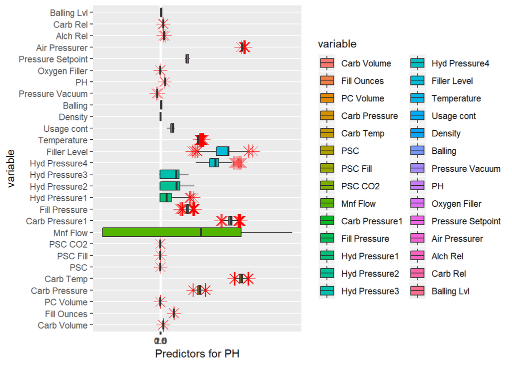

```r
df.m <- melt(bev_raw %>% select(-MFR, -`Filler Speed`, -`Carb Flow`,-`Bowl Setpoint`,`Carb Pressure1`,
            `Hyd Pressure4`, `Air Pressurer`, `Carb Temp`, `Filler Level`, `Mnf Flow`), id.var = "Brand Code")
p <-ggplot(data = df.m, aes(x=variable, y=value)) +
  geom_boxplot(outlier.colour="red", outlier.shape=8, outlier.size=4,aes(fill=variable)) +
  scale_y_continuous(name = "Predictors for PH", breaks = seq(0, 2, 0.5))  +
  coord_flip()
p
```

### Normality

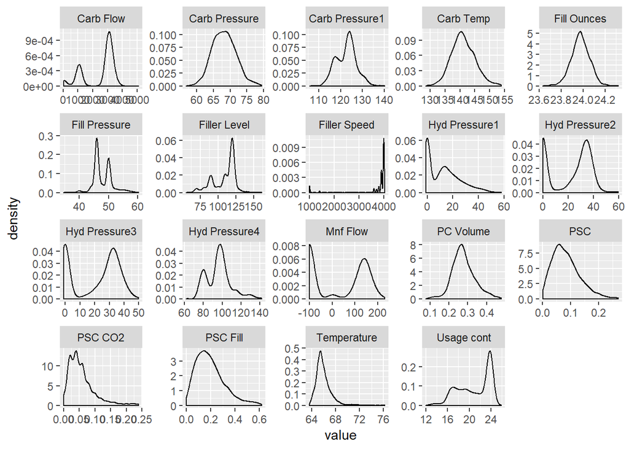

```r
bev_raw%>%
 select(-`Brand Code`) %>%
  select(2:20) %>%
  gather() %>%
  ggplot(aes(value)) +
    facet_wrap(~ key, scales = "free") +
    geom_density()
```

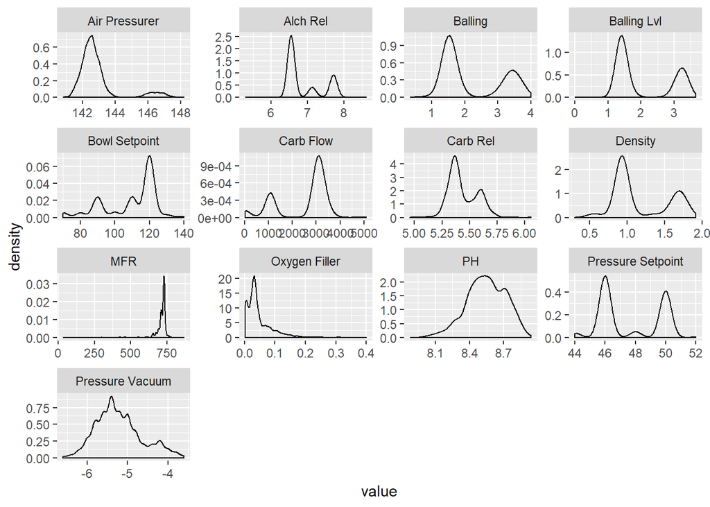

```r
bev_raw%>%
 select(-`Brand Code`) %>%
  select(`Carb Flow`, Density, MFR, Balling, `Pressure Vacuum`, PH, `Oxygen Filler`, `Bowl Setpoint`, `Pressure Setpoint`, `Air Pressurer`, `Alch Rel`,`Carb Rel`,`Balling Lvl`)   %>%
  gather() %>%
  ggplot(aes(value)) +
    facet_wrap(~ key, scales = "free") +
    geom_density()
```

## Prep Data

We perform 3 data preparation steps - Remove the near-zero variance variables we previously mentioned - Impute missing values with a Random Forest Regression with the MICE package - Create dummy variables for the categorical variable, brand

Random Forest was chosen as the regression method in imputation because it requires very little tuning, allowing and there is no interface to tune the imputation model in MICE.

```r
cl <- makeCluster(detectCores())
registerDoParallel(cl)
set.seed(42)

bev <- select(bev_raw, -PH) %>%
  union_all(se_data) #since we're not using the labels (y values), combining the sets for data clearning is fine
cols <- str_replace(colnames(bev), '\\s', '')
colnames(bev) <- cols
bev <- mutate(bev, BrandCode = ifelse(is.na(BrandCode), 'Unknown', BrandCode))
y <- bev_raw$PH

zero_vars <- nearZeroVar(bev[1:2566, ])
bev_new <- bev[, -zero_vars]

pred <- mice(data = bev_new, m = 3, method = 'rf', maxit = 3)
bev_imputed <- complete(pred)

form <- dummyVars(~ ., data = bev_imputed)
bev_imputed <- predict(form, bev_imputed) %>% data.frame() %>% as.matrix()
```

### Test Train Split

We will split the data into train/test sets before running cross validation. This will allow us to make sure that predictions are consistent at all levels of PH.

```r
bev_eval <- bev_imputed[2567:2833,]
bev_train <- bev_imputed[1:2566,]
samples <- createDataPartition(y, p = .75, list = F)
x_train <- bev_train[samples, ]
x_test<- bev_train[-samples, ]

y_train <- y[samples]
y_test <- y[-samples]
```

## Build Models

For state-of-the-art prediction quality, we will use a model stack. This will consist of tuning models separately and then combining the candidate models into a metamodel that will formulate predictions with a linear combination of our tuned models.

From the perspective of understanding the manufacturing process, the model stack will also provide benefits. The stack is like a panel of experts, each looking at the data through slightly different lenses to form their diagnoses. By looking at the predictors each model uses, we can gather assemble a complete picture of the factors that affect our manufacturing process.

```r
#xgb_grid <- expand.grid(eta = c(.01,.025), nrounds = c(750,1000), max_depth = c(5,6,7), gamma = c(.1,0), colsample_bytree = c(.8), min_child_weight = c(.4,.8), subsample = c(.8))
#cub_grid <- expand.grid(.committees = c(1,3,5), .neighbors = c(1,3,5,7,9))
#mars_grid <- expand.grid(.degree = c(1,2), .nprune = seq(16,36,4))
#dart_grid <- expand.grid(eta = c(.025), nrounds = c(1000), gamma = c(.001,.1), skip_drop = c(.4,.8), rate_drop = c(.4,.8), #max_depth = c(6,7,8), colsample_bytree = c(.8), min_child_weight = c(.8), subsample = c(.8))
#rf_grid <- expand.grid(mtry = c(5,10,15,20,25,30))

xgb_grid <- expand.grid(eta = c(.01), nrounds = c(1000), max_depth = c(6), gamma = c(0), colsample_bytree = c(.8), min_child_weight = c(.8), subsample = c(.8))
cub_grid <- expand.grid(.committees = c(5), .neighbors = c(7))
mars_grid <- expand.grid(.degree = c(2), .nprune = 24)
dart_grid <- expand.grid(eta = c(.01), nrounds = c(1000), gamma = c(.1), skip_drop = c(.6), rate_drop = c(.4), max_depth = c(6), colsample_bytree = c(.6), min_child_weight = c(.6), subsample = c(.6))
rf_grid <- expand.grid(mtry = 25)

tuning_list <-list(
  caretModelSpec(method="xgbTree", tuneGrid = xgb_grid),
  caretModelSpec(method="xgbDART", tuneGrid = dart_grid),
  caretModelSpec(method="cubist", tuneGrid = cub_grid),
  caretModelSpec(method="rf", tuneGrid = rf_grid, importance = TRUE),
  caretModelSpec(method="bagEarth", tuneGrid = mars_grid)
)

my_control <- trainControl(method = 'cv',
                           number = 5,
                           savePredictions = 'final',
                           index = createFolds(y_train, 5),
                           allowParallel = TRUE)

mod_list <- caretList(
  x = x_train,
  y = y_train,
  preProcess = c('center', 'scale'),
  trControl = my_control,
  tuneList = tuning_list
)
```

*The training grid is commented out because of the time required to run, but can be uncommented for reproducibility of our model optimization*

### MARS

```r
#helper function
show_results <- function(model){
  rslts <- model$results %>%
    arrange(RMSE)
  head(rslts, 10) %>% kable () %>% kable_styling(bootstrap_options = "striped", full_width = F)
}
```

```r
show_results(mod_list$bagEarth)
```

| degree | nprune | RMSE | Rsquared | MAE | RMSESD | RsquaredSD | MAESD |
| --- | --- | --- | --- | --- | --- | --- | --- |
| 2 | 24 | 0.1302201 | 0.4178209 | 0.0979479 | 0.0035633 | 0.0287038 | 0.0017327 |

```r
#plot(mod_list$mars, metric = "RMSE")
```

```r
predict(mod_list$bagEarth, x_test) %>%
  postResample(y_test)
```

```
##       RMSE   Rsquared        MAE
## 0.11515201 0.58228779 0.08734484
```

### RandomForest

```r
show_results(mod_list$rf)
```

| mtry | RMSE | Rsquared | MAE | RMSESD | RsquaredSD | MAESD |
| --- | --- | --- | --- | --- | --- | --- |
| 25 | 0.1239753 | 0.4745176 | 0.0945754 | 0.0035971 | 0.0310322 | 0.002074 |

```r
predict(mod_list$rf, x_test) %>%
  postResample(y_test)
```

```
##       RMSE   Rsquared        MAE
## 0.09354960 0.73650818 0.06758841
```

### Cubist

```r
show_results(mod_list$cubist)
```

| committees | neighbors | RMSE | Rsquared | MAE | RMSESD | RsquaredSD | MAESD |
| --- | --- | --- | --- | --- | --- | --- | --- |
| 5 | 7 | 0.1263829 | 0.460551 | 0.0949511 | 0.0019827 | 0.0047366 | 0.0015366 |

```r
#plot(mod_list$cub, metric = "RMSE")
```

```r
predict(mod_list$cubist, x_test) %>%
  postResample(y_test)
```

```
##       RMSE   Rsquared        MAE
## 0.09987485 0.68170870 0.06952931
```

### XGB Trees

```r
show_results(mod_list$xgbTree)
```

| eta | nrounds | max_depth | gamma | colsample_bytree | min_child_weight | subsample | RMSE | Rsquared | MAE | RMSESD | RsquaredSD | MAESD |
| --- | --- | --- | --- | --- | --- | --- | --- | --- | --- | --- | --- | --- |
| 0.01 | 1000 | 6 | 0 | 0.8 | 0.8 | 0.8 | 0.1251791 | 0.4602745 | 0.0947012 | 0.0022701 | 0.0169645 | 0.0013845 |

```r
#plot(mod_list$xgbt, metric = "RMSE")
```

```r
predict(mod_list$xgbTree, x_test) %>%
  postResample(y_test)
```

```
##       RMSE   Rsquared        MAE
## 0.09940888 0.69337838 0.07274608
```

### XGB Dart

```r
show_results(mod_list$xgbDART)
```

| eta | nrounds | gamma | skip_drop | rate_drop | max_depth | colsample_bytree | min_child_weight | subsample | RMSE | Rsquared | MAE | RMSESD | RsquaredSD | MAESD |
| --- | --- | --- | --- | --- | --- | --- | --- | --- | --- | --- | --- | --- | --- | --- |
| 0.01 | 1000 | 0.1 | 0.6 | 0.4 | 6 | 0.6 | 0.6 | 0.6 | 0.1334267 | 0.4150649 | 0.1061022 | 0.0022785 | 0.0251741 | 0.0020912 |

```r
#plot(mod_list$xgbd, metric = "RMSE")
```

```r
predict(mod_list$xgbDART, x_test) %>%
  postResample(y_test)
```

```
##       RMSE   Rsquared        MAE
## 0.11217078 0.64232329 0.08773697
```

**Assessment**

### Variable Importances

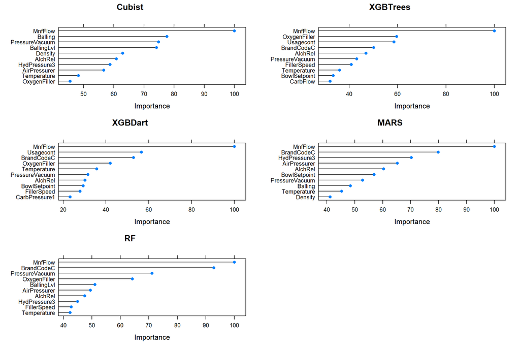

```r
p1 <- varImp(mod_list$cubist) %>%
  plot(top = 10, main = 'Cubist')
p2 <- varImp(mod_list$xgbTree) %>%
  plot(top = 10, main = 'XGBTrees')
p3 <- varImp(mod_list$xgbDART) %>%
  plot(top = 10, main = 'XGBDart')
p4 <- varImp(mod_list$bagEarth) %>%
  plot(top = 10, main = 'MARS')
p5 <- varImp(mod_list$rf) %>%
  plot(top = 10, main = 'RF')
grid.arrange(p1,p2,p3,p4,p5, nrow = 3, ncol = 2)
```

Observations:

- The top predictor, MnFlow, is consistent throughout the set of models
- The XGBoost models are similar in variables, but less similar in their distributions of importance
- After the top 5, divergence increases

Based on what we see, there are more factors contributing to PH with the ensemble than with a single model. We’ll confirm this by looking at the count by predictor among each top 10:

**Variable Counts among the Models**

```r
top_10 <- function(model) {
  varImp(model)$importance %>%
  rownames_to_column('var') %>%
  arrange(desc(Overall)) %>%
  head(10) %>%
  select(var)
}

rbind(top_10(mod_list$xgbDART), top_10(mod_list$xgbTree), top_10(mod_list$cubist), top_10(mod_list$bagEarth), top_10(mod_list$rf)) %>%
  group_by(var) %>%
  summarise(ModelCount = n()) %>%
  arrange(desc(ModelCount)) %>%
  kable () %>% kable_styling(bootstrap_options = "striped", full_width = F)
```

| var | ModelCount |
| --- | --- |
| AlchRel | 5 |
| MnfFlow | 5 |
| PressureVacuum | 5 |
| Temperature | 5 |
| BrandCodeC | 4 |
| OxygenFiller | 4 |
| AirPressurer | 3 |
| BowlSetpoint | 3 |
| FillerSpeed | 3 |
| HydPressure3 | 3 |
| Balling | 2 |
| BallingLvl | 2 |
| Density | 2 |
| Usagecont | 2 |
| CarbFlow | 1 |
| CarbPressure1 | 1 |

**Best Single Tree**

Because 4 of the 5 models in the ensemble are tree-based, looking a single decision tree model will give us an idea of not just what predictors are important, but how they are being used to form predictions.

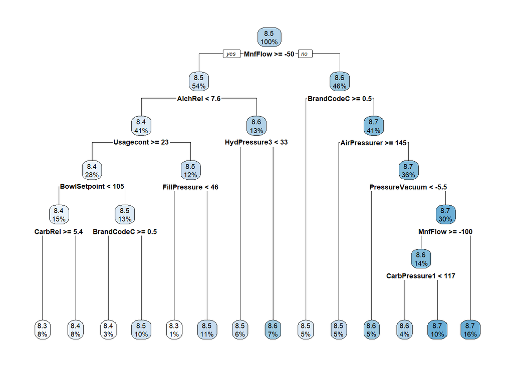

```r
rp_mod <- rpart::rpart(ph ~ ., data = data.frame(bev_train, ph = y), method = 'anova')
rpart.plot(rp_mod, uniform=TRUE)
```

#### Test Model Stack

Now that our models are optimized and understood, we will form the ensemble and test the results. We first look at their prediction correlations to confirm that the stack, intuitively, be effective. The lower the correlation between the models, the more effective the stack will be.

```r
resamples <- resamples(mod_list)
modelCor(resamples) %>% kable() %>% kable_styling(bootstrap_options = "striped", full_width = F)
```

|  | xgbTree | xgbDART | cubist | rf | bagEarth |
| --- | --- | --- | --- | --- | --- |
| xgbTree | 1.0000000 | 0.8394105 | -0.7417804 | -0.0638124 | 0.6832539 |
| xgbDART | 0.8394105 | 1.0000000 | -0.4850035 | -0.2766800 | 0.7920211 |
| cubist | -0.7417804 | -0.4850035 | 1.0000000 | -0.6149653 | -0.7807486 |
| rf | -0.0638124 | -0.2766800 | -0.6149653 | 1.0000000 | 0.3455615 |
| bagEarth | 0.6832539 | 0.7920211 | -0.7807486 | 0.3455615 | 1.0000000 |

*Our model list has negative correlations, indicating that it will be effective.*

```r
ensemble1 <- caretStack(
  mod_list,
  method="glmnet",
  metric="RMSE",
  trControl=trainControl(
    method="cv",
    number=5,
    savePredictions="final"
  )
)
ensemble1$ens_model$results %>% kable () %>% kable_styling(bootstrap_options = "striped", full_width = F)
```

| alpha | lambda | RMSE | Rsquared | MAE | RMSESD | RsquaredSD | MAESD |
| --- | --- | --- | --- | --- | --- | --- | --- |
| 0.10 | 0.0002339 | 0.1195489 | 0.5060443 | 0.0889906 | 0.0041998 | 0.0217873 | 0.0031864 |
| 0.10 | 0.0023387 | 0.1196843 | 0.5050046 | 0.0892782 | 0.0041414 | 0.0213619 | 0.0030519 |
| 0.10 | 0.0233868 | 0.1209226 | 0.4961712 | 0.0910859 | 0.0039858 | 0.0207479 | 0.0028217 |
| 0.55 | 0.0002339 | 0.1195549 | 0.5059956 | 0.0890103 | 0.0041861 | 0.0216827 | 0.0031730 |
| 0.55 | 0.0023387 | 0.1200706 | 0.5018781 | 0.0898742 | 0.0040324 | 0.0205045 | 0.0029483 |
| 0.55 | 0.0233868 | 0.1216414 | 0.4968121 | 0.0922782 | 0.0037659 | 0.0202408 | 0.0026992 |
| 1.00 | 0.0002339 | 0.1195626 | 0.5059374 | 0.0890362 | 0.0041759 | 0.0216093 | 0.0031610 |
| 1.00 | 0.0023387 | 0.1206849 | 0.4968067 | 0.0907271 | 0.0039656 | 0.0199970 | 0.0028892 |
| 1.00 | 0.0233868 | 0.1230640 | 0.4965697 | 0.0941356 | 0.0035556 | 0.0197696 | 0.0025979 |

*We see a several percent improvement over the best single model.*

```r
preds <- predict(ensemble1, x_test)
preds %>% postResample(y_test)
```

```
##       RMSE   Rsquared        MAE
## 0.09036733 0.74478118 0.06319195
```

**Predicted Vs Actual**

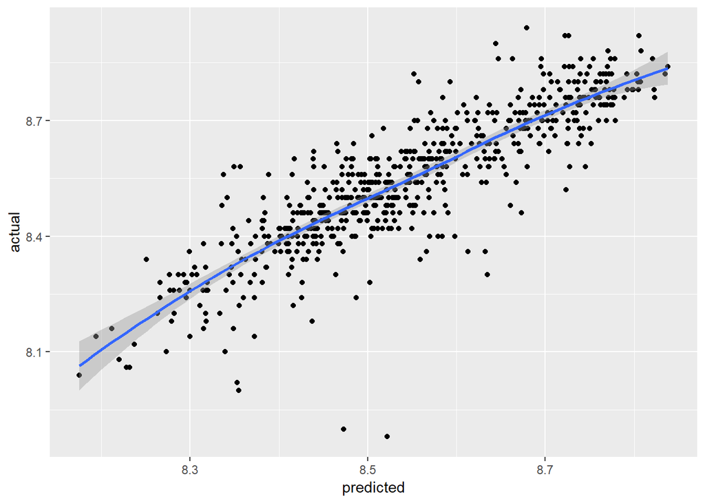

```r
preds_df <- data.frame(predicted = preds, actual = y_test)
ggplot(preds_df) + geom_point(aes(x = predicted, y = actual)) + geom_smooth(aes(x = predicted, y = actual))
```

On the test set, the ensemble’s predictions are consistent throughout the range of PH. Consistent quality is, theoretically, a feature of ensemble models because the models are weighted such that predictions are maximized. If one model predicts better at lower PH, it will be upweighted over that range. There are several outliers, but when not all of the variance is explainable, this is unavoidable.

## Predict on Eval Set

With our hyperparameters of the individual models optimized, we want to provide each model the entire training set and build the meta-model based on these optimized single models.

```r
xgb_grid <- expand.grid(eta = c(.01), nrounds = c(1000), max_depth = c(6), gamma = c(0), colsample_bytree = c(.8), min_child_weight = c(.8), subsample = c(.8))
cub_grid <- expand.grid(.committees = c(5), .neighbors = c(7))
mars_grid <- expand.grid(.degree = c(2), .nprune = 24)
dart_grid <- expand.grid(eta = c(.01), nrounds = c(1000), gamma = c(.1), skip_drop = c(.6), rate_drop = c(.4), max_depth = c(6), colsample_bytree = c(.6), min_child_weight = c(.6), subsample = c(.6))
rf_grid <- expand.grid(mtry = 25)

tuning_list <-list(
  caretModelSpec(method="xgbTree", tuneGrid = xgb_grid),
  caretModelSpec(method="xgbDART", tuneGrid = dart_grid),
  caretModelSpec(method="cubist", tuneGrid = cub_grid),
  caretModelSpec(method="rf", tuneGrid = rf_grid, importance = TRUE),
  caretModelSpec(method="bagEarth", tuneGrid = mars_grid)
)



my_control <- trainControl(method = 'cv',
                           number = 5,
                           savePredictions = 'final',
                           index = createFolds(y, 5),
                           allowParallel = TRUE)

mod_list <- caretList(
  x = bev_train,
  y = y,
  preProcess = c('center', 'scale'),
  trControl = my_control,
  tuneList = tuning_list
)
final_ensemble <- caretStack(
  mod_list,
  method="glmnet",
  metric="RMSE",
  trControl=trainControl(
    method="cv",
    number=5,
    savePredictions="final"
  )
)
final_ensemble$ens_model$results %>% kable () %>% kable_styling(bootstrap_options = "striped", full_width = F)
```

| alpha | lambda | RMSE | Rsquared | MAE | RMSESD | RsquaredSD | MAESD |
| --- | --- | --- | --- | --- | --- | --- | --- |
| 0.10 | 0.0002528 | 0.1131713 | 0.5660807 | 0.0839502 | 0.0020688 | 0.0173741 | 0.0021009 |
| 0.10 | 0.0025277 | 0.1134130 | 0.5642861 | 0.0844183 | 0.0021643 | 0.0183437 | 0.0021718 |
| 0.10 | 0.0252771 | 0.1151647 | 0.5524864 | 0.0866250 | 0.0022178 | 0.0196344 | 0.0021919 |
| 0.55 | 0.0002528 | 0.1131711 | 0.5660820 | 0.0839712 | 0.0020718 | 0.0174038 | 0.0021080 |
| 0.55 | 0.0025277 | 0.1138764 | 0.5607793 | 0.0850605 | 0.0022118 | 0.0188878 | 0.0021812 |
| 0.55 | 0.0252771 | 0.1158924 | 0.5545486 | 0.0876969 | 0.0020873 | 0.0191962 | 0.0021890 |
| 1.00 | 0.0002528 | 0.1131797 | 0.5660181 | 0.0839999 | 0.0020744 | 0.0174472 | 0.0021137 |
| 1.00 | 0.0025277 | 0.1146397 | 0.5548946 | 0.0859919 | 0.0022184 | 0.0190981 | 0.0021461 |
| 1.00 | 0.0252771 | 0.1175212 | 0.5545674 | 0.0895618 | 0.0019695 | 0.0187259 | 0.0022163 |

*With more data available, the ensemble improve around 6%. Our model is considerably more predictive than a “baseline” single model.*

**Ensemble Model Importances**

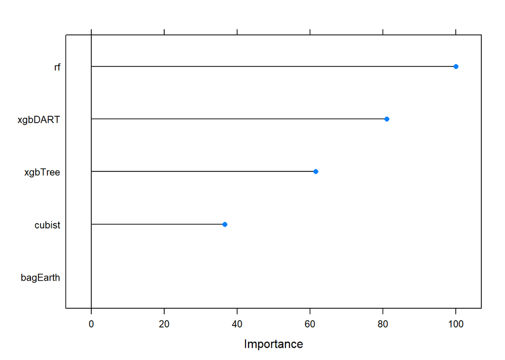

```r
plot(varImp(final_ensemble$ens_model))
```

*The MARS model is excluded, but all four tree models contribute the the final prediction*

**Export Predictions**

```r
predictions <- predict(final_ensemble, bev_eval)
predictions %>% tibble::enframe(name = NULL) %>% datatable()
```

|  | value |
| --- | --- |
| 1 | 8.5411615191258 |
| 2 | 8.39454005451922 |
| 3 | 8.47994372363643 |
| 4 | 8.58808499438833 |
| 5 | 8.42552712237902 |
| 6 | 8.50757160536318 |
| 7 | 8.47502106518746 |
| 8 | 8.58562109683267 |
| 9 | 8.51746403119161 |
| 10 | 8.63578367387298 |

[output cut: 257 more lines]

```r
write.csv(predictions, file = "predictions.csv")
```